# Pew Global

Aaron Grenz & Marie Marshall

### Question #1

Overall, are you satisfied or dissatisfied with the way things are going in our country today?

[interactive chart not shown]

This graph displays the responses from 1002 United States citizens answer to the question. Interestingly, the most common response was “dissatisfied”. A total of 688 people stated they were dissatisfied with the way things are going in our country today. On the other hand, 293 people stated they were satisfied. In the United States, the majority of individuals are dissatisfied with the way things are going in our country today.

### Question #4

Now thinking about our economic situation, how would you describe the current economic situation in the United States - is it very good, somewhat good, somewhat bad or very bad?

[interactive chart not shown]

This graph displays the responses from 1002 United States citizens answer to the question. In the United States, the majority of individuals believe the country’s ecocomy is somewhat bad. About the same frequency of individuals believe the economy is somewhat good as very bad, as well.

### Question #5

And over the next 12 months do you expect the economic situation in our country to improve a lot, improve a little, remain the same, worsen a little or worsen a lot?

[interactive chart not shown]

This graph displays the responses from 1002 United States citizens answer to the question. In the United States, the majority of individuals expect the country’s economic situation to “improve a little”.

### Question #6

Now thinking about your personal economic situation, how would you describe it - is it very good, somewhat good, somewhat bad or very bad?

[interactive chart not shown]

In the United States, the majority of individuals believe their personal financial situation is “somewhat good”.

### Question #7

And over the next 12 months do you expect your personal economic situation to improve a lot, improve a little, remain the same, worsen a little or worsen a lot?

[interactive chart not shown]

In the United Sates the majority of individuals expect their personal economic situation to remain the same over the next 12 months.

### Question #8

When children today in the United States grow up, do you think they will be better off or worse off financially than their parents?

[interactive chart not shown]

In the United States the majority of individuals believe that children today will worse off financially than their parents.

### Question #47US

In making international policy decisions, to what extent do you think the United States takes into account the interests of other countries around the world - a great deal, a fair amount, not too much, or not at all?

[interactive chart not shown]

In the United States the majority of individuals believe the United States takes into account the interests of other countries around the world a fair amount.

### Question #164

Gender (RECORD BY OBSERVATION).

[interactive chart not shown]

This graph displays the gender of survey respondents in the United Stated. It was simply recorded by observation. The graph shows that there was thirty-six more females who took the survey than males.

### Question #165

How old were you at your last birthday?

[interactive chart not shown]

This graph displays the age range for the United States respondents. This graph shows the pew research team surveyed a wide range of ages.

### Question Political Party in the US

In politics TODAY, do you consider yourself a Republican, Democrat, or Independent?

[interactive chart not shown]

In the United States, the majority of idividuals claimed they were Independent.

### Question Political Party Lean in the US

As of today do you lean more to the Republican Party or more to the Democratic Party?

[interactive chart not shown]

In the United States, the majority of idividuals lean more to the Democratic party.

### Extra Graphs

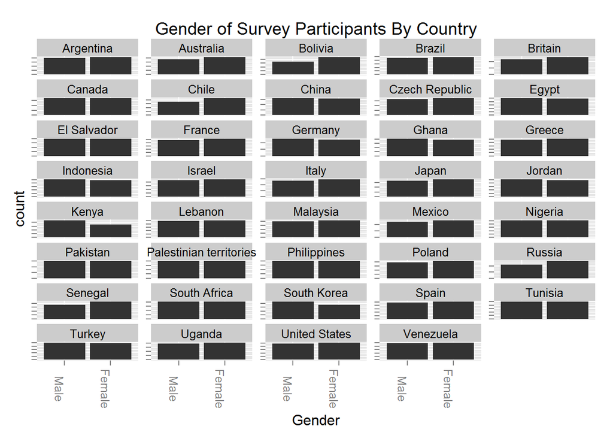

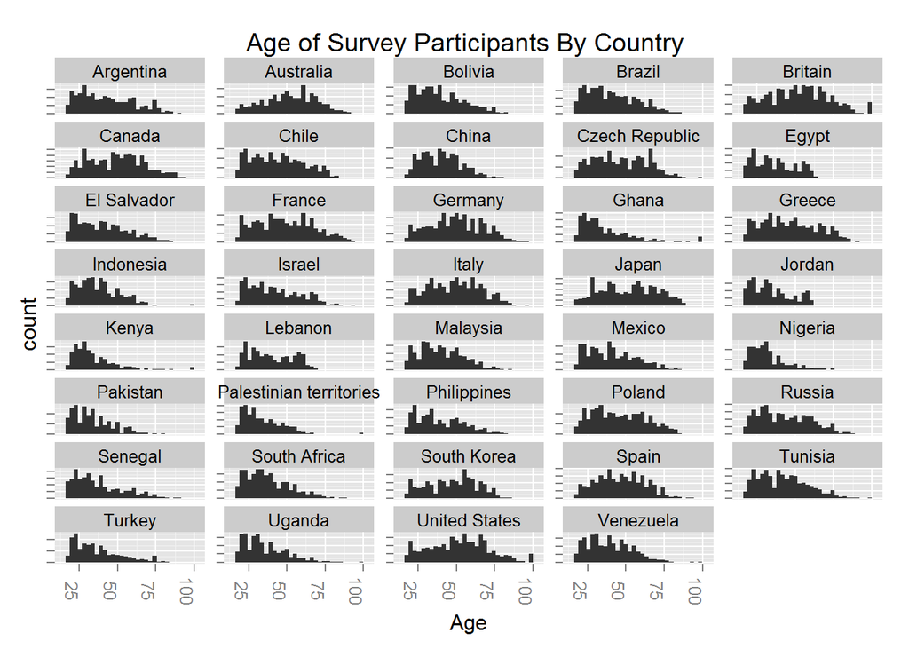